# Introduction

## Complexity of Phosphorous

# Plants as Phosphate sinks

```r
#|include: false
#|echo: false

library(multcomp)
library(car)
library(tidyr)
library(lme4)
library(ggplot2)
library(ggtext)
library(ggpmisc)
library(nlme)
library(latex2exp)
library(kableExtra)
library(broom)
library(dplyr)
library(MuMIn)
library(sjPlot) # table functions
library(sjmisc) # sample data
library(lme4) # fitting models
library(report)
library(performance)

load("~/Documents/Master Thesis/Master-Thesis-P-kinetics/data/results_coefficient_analysis")
```

## Research Questions:

### How well can current GRUD measurements of $C_P$ predict the relative Yield, P-Uptake and P-Balance?

- Hypothesis I: The measurements of the equlibrium concentrations of Phosphorus in a solvent do not display significant effects on relative Yield and consequently P-Uptake, since it is strongly dependent on yield. $C_P$ relates strongly to the amount of Phosphorus applied, the P-balance might well be siginificantly correlated to $C_P$ but not explain a lot of variance.

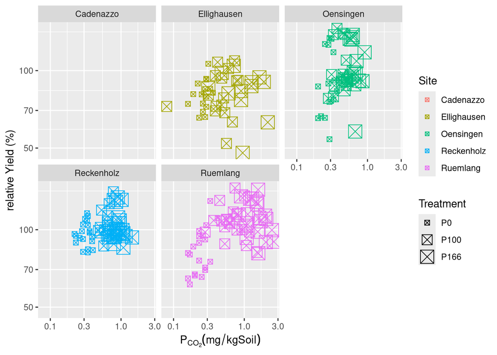

```r
#|code-fold: true
#|tidy: true
#|echo: false

ggplot(D[D$soil_0_20_P_CO2!=0,],aes(y=Ymain_rel, x=soil_0_20_P_CO2, col=Site, size = Treatment)) +
  geom_point(shape = 7) +
  scale_x_log10() + scale_y_log10() +
  labs(x=TeX("$P_{CO_{2}}(mg/kg Soil)$"),
         y="relative Yield (%)") +
  facet_wrap( ~ Site, nrow = 2)
```

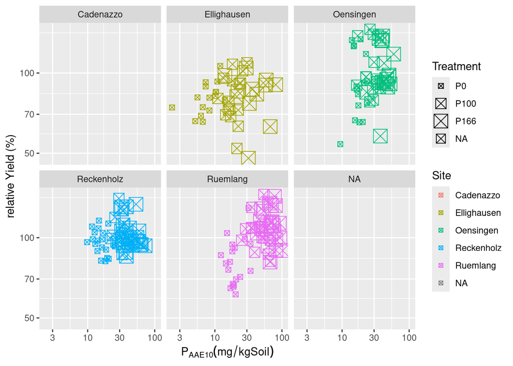

```r
ggplot(D[D$soil_0_20_P_AAE10!=0,],aes(y=Ymain_rel, x=soil_0_20_P_AAE10, col=Site, size = Treatment)) +
  geom_point(shape = 7) +
  scale_x_log10() + scale_y_log10() +
  labs(x=TeX("$P_{AAE10}(mg/kg Soil)$"),
         y="relative Yield (%)") +
  facet_wrap( ~ Site, nrow = 2)
```

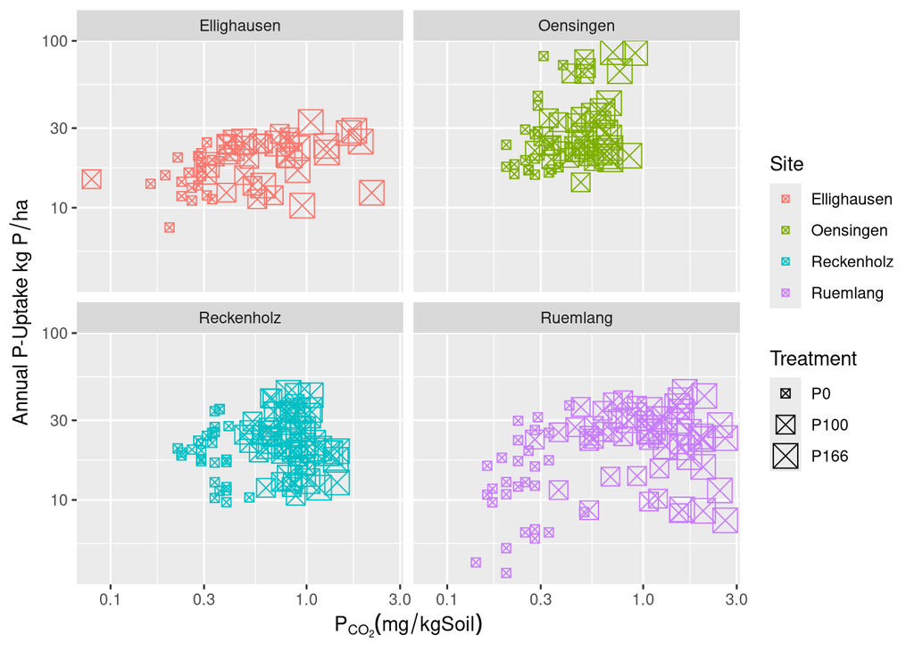

```r
ggplot(D[D$soil_0_20_P_CO2!=0&D$annual_P_uptake!=0,],aes(y=annual_P_uptake, x=soil_0_20_P_CO2, col=Site, size = Treatment)) +
  geom_point(shape = 7) +
  scale_x_log10() + scale_y_log10() +
  labs(x=TeX("$P_{CO_{2}}(mg/kg Soil)$"),
         y=TeX("Annual P-Uptake $kg~P/ha$")) +
  facet_wrap( ~ Site, nrow = 2)
```

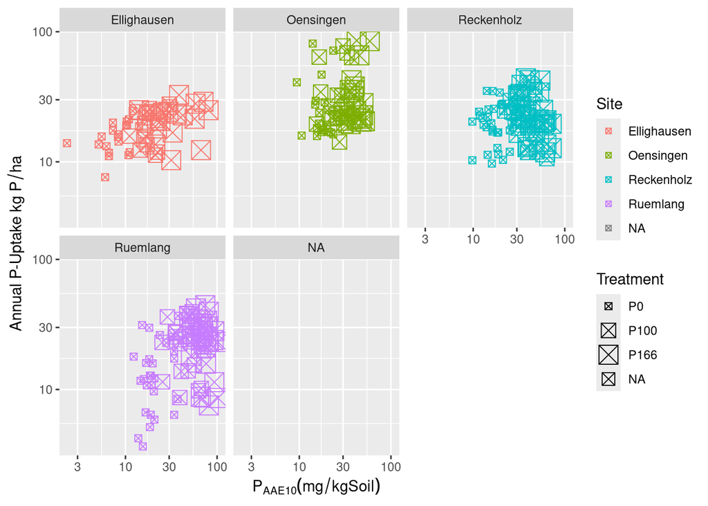

```r
ggplot(D[D$soil_0_20_P_AAE10!=0&D$annual_P_uptake!=0,],aes(y=annual_P_uptake, x=soil_0_20_P_AAE10, col=Site, size = Treatment)) +
  geom_point(shape = 7) +
  scale_x_log10() + scale_y_log10() +
  labs(x=TeX("$P_{AAE10}(mg/kg Soil)$"),
         y=TeX("Annual P-Uptake $kg~P/ha$")) +
  facet_wrap( ~ Site, nrow = 2)
```

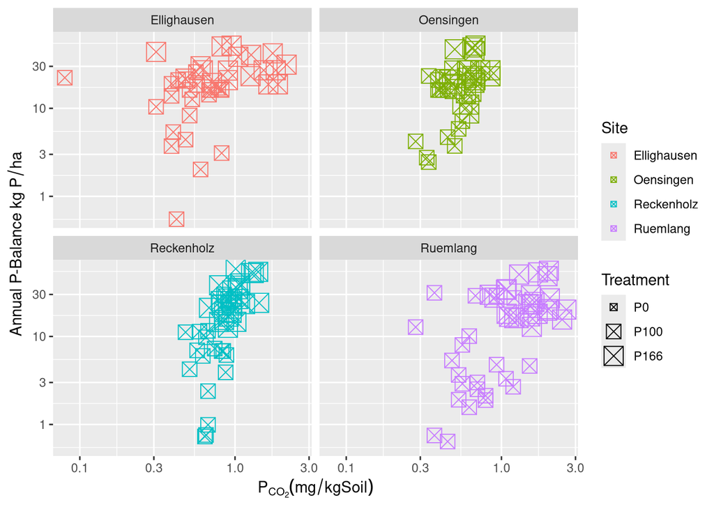

```r
ggplot(D[D$soil_0_20_P_CO2!=0&D$annual_P_balance!=0,],aes(y=annual_P_balance, x=soil_0_20_P_CO2, col=Site, size = Treatment)) +
  geom_point(shape = 7) +
  scale_x_log10() + scale_y_log10() +
  labs(x=TeX("$P_{CO_{2}}(mg/kg Soil)$"),
         y=TeX("Annual P-Balance $kg~P/ha$")) +
  facet_wrap( ~ Site, nrow = 2)
```

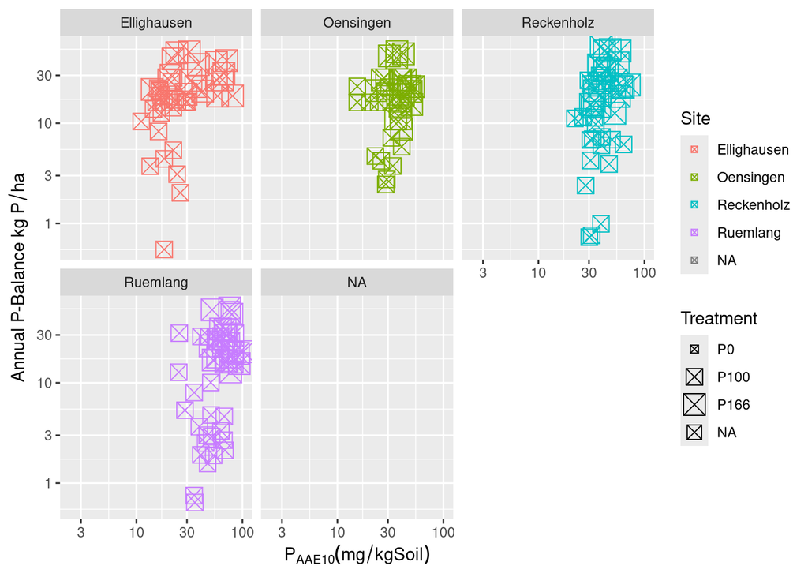

```r
ggplot(D[D$soil_0_20_P_AAE10!=0&D$annual_P_balance!=0,],aes(y=annual_P_balance, x=soil_0_20_P_AAE10, col=Site, size = Treatment)) +
  geom_point(shape = 7) +
  scale_x_log10() + scale_y_log10() +
  labs(x=TeX("$P_{AAE10}(mg/kg Soil)$"),
         y=TeX("Annual P-Balance $kg~P/ha$")) +
  facet_wrap( ~ Site, nrow = 2)
```

Now we want to check the strength of the models in terms of $R^2$ and the significance of the effects in terms of p-values:

```r
#|code-fold: true
#|tidy: true
#|echo: false

#tab_model(fit.grud.Yrel,fit.grud.Puptake,fit.grud.Pbalance)
report(fit.grud.Yrel)
```

```
Formula contains log- or sqrt-terms.
  See help("standardize") for how such terms are standardized.
```

```
boundary (singular) fit: see help('isSingular')
```

```
Formula contains log- or sqrt-terms.
  See help("standardize") for how such terms are standardized.
```

```
boundary (singular) fit: see help('isSingular')
```

```
We fitted a linear mixed model (estimated using REML and nloptwrap optimizer)
to predict Ymain_rel with soil_0_20_P_CO2, soil_0_20_P_AAE10 and Treatment
(formula: Ymain_rel ~ log(soil_0_20_P_CO2) + log(soil_0_20_P_AAE10) +
Treatment). The model included year as random effects (formula: list(~1 | year,
~1 | Site, ~1 | Site:block, ~1 | Site:Treatment)). The model's total
explanatory power is substantial (conditional R2 = 0.58) and the part related
to the fixed effects alone (marginal R2) is of 0.10. The model's intercept,
corresponding to soil_0_20_P_CO2 = 0, soil_0_20_P_AAE10 = 0 and Treatment = P0,
is at 70.66 (95% CI [38.22, 103.10], t(202) = 4.30, p < .001). Within this
model:

  - The effect of soil 0 20 P CO2 [log] is statistically non-significant and
positive (beta = 1.16, 95% CI [-6.67, 8.98], t(202) = 0.29, p = 0.771; Std.
beta = -0.28, 95% CI [-0.97, 0.42])
  - The effect of soil 0 20 P AAE10 [log] is statistically non-significant and
positive (beta = 8.10, 95% CI [-0.14, 16.33], t(202) = 1.94, p = 0.054; Std.
beta = 0.93, 95% CI [0.17, 1.68])
  - The effect of Treatment [P100] is statistically non-significant and positive
(beta = 4.06, 95% CI [-5.90, 14.02], t(202) = 0.80, p = 0.422; Std. beta =
0.29, 95% CI [-0.18, 0.76])
  - The effect of Treatment [P166] is statistically non-significant and positive
(beta = 1.60, 95% CI [-10.64, 13.84], t(202) = 0.26, p = 0.797; Std. beta =
0.20, 95% CI [-0.39, 0.80])

Standardized parameters were obtained by fitting the model on a standardized
version of the dataset. 95% Confidence Intervals (CIs) and p-values were
computed using a Wald t-distribution approximation.
```

```r
report(fit.grud.Puptake)
```

```
Formula contains log- or sqrt-terms.
  See help("standardize") for how such terms are standardized.
boundary (singular) fit: see help('isSingular')
```

```
Random effect variances not available. Returned R2 does not account for random effects.
```

```
Formula contains log- or sqrt-terms.
  See help("standardize") for how such terms are standardized.
boundary (singular) fit: see help('isSingular')
```

```
Random effect variances not available. Returned R2 does not account for random effects.
```

```
We fitted a linear mixed model (estimated using REML and nloptwrap optimizer)
to predict annual_P_uptake with soil_0_20_P_CO2, soil_0_20_P_AAE10 and
Treatment (formula: annual_P_uptake ~ log(soil_0_20_P_CO2) +
log(soil_0_20_P_AAE10) + Treatment). The model included year as random effects
(formula: list(~1 | year, ~1 | Site, ~1 | Site:block, ~1 | Site:Treatment)).
The model's explanatory power related to the fixed effects alone (marginal R2)
is 0.05. The model's intercept, corresponding to soil_0_20_P_CO2 = 0,
soil_0_20_P_AAE10 = 0 and Treatment = P0, is at 14.25 (95% CI [-3.31, 31.81],
t(402) = 1.59, p = 0.112). Within this model:

  - The effect of soil 0 20 P CO2 [log] is statistically non-significant and
positive (beta = 2.08, 95% CI [-1.75, 5.92], t(402) = 1.07, p = 0.286; Std.
beta = 0.15, 95% CI [-0.29, 0.60])
  - The effect of soil 0 20 P AAE10 [log] is statistically non-significant and
positive (beta = 0.82, 95% CI [-3.27, 4.91], t(402) = 0.40, p = 0.693; Std.
beta = 0.16, 95% CI [-0.35, 0.66])
  - The effect of Treatment [P100] is statistically non-significant and positive
(beta = 1.52, 95% CI [-2.04, 5.09], t(402) = 0.84, p = 0.401; Std. beta = 0.12,
95% CI [-0.10, 0.35])
  - The effect of Treatment [P166] is statistically non-significant and positive
(beta = 1.18, 95% CI [-3.83, 6.19], t(402) = 0.46, p = 0.643; Std. beta = 0.10,
95% CI [-0.22, 0.42])

Standardized parameters were obtained by fitting the model on a standardized
version of the dataset. 95% Confidence Intervals (CIs) and p-values were
computed using a Wald t-distribution approximation.
```

```r
report(fit.grud.Pbalance)
```

```
Formula contains log- or sqrt-terms.
  See help("standardize") for how such terms are standardized.
boundary (singular) fit: see help('isSingular')
```

```
Random effect variances not available. Returned R2 does not account for random effects.
```

```
Formula contains log- or sqrt-terms.
  See help("standardize") for how such terms are standardized.
boundary (singular) fit: see help('isSingular')
```

```
Random effect variances not available. Returned R2 does not account for random effects.
```

```
We fitted a linear mixed model (estimated using REML and nloptwrap optimizer)
to predict annual_P_balance with soil_0_20_P_CO2, soil_0_20_P_AAE10 and
Treatment (formula: annual_P_balance ~ log(soil_0_20_P_CO2) +
log(soil_0_20_P_AAE10) + Treatment). The model included year as random effects
(formula: list(~1 | year, ~1 | Site, ~1 | Site:block, ~1 | Site:Treatment)).
The model's explanatory power related to the fixed effects alone (marginal R2)
is 0.51. The model's intercept, corresponding to soil_0_20_P_CO2 = 0,
soil_0_20_P_AAE10 = 0 and Treatment = P0, is at -16.64 (95% CI [-35.71, 2.43],
t(402) = -1.72, p = 0.087). Within this model:

  - The effect of soil 0 20 P CO2 [log] is statistically significant and negative
(beta = -5.00, 95% CI [-9.65, -0.35], t(402) = -2.12, p = 0.035; Std. beta =
-0.05, 95% CI [-0.48, 0.37])
  - The effect of soil 0 20 P AAE10 [log] is statistically non-significant and
negative (beta = -1.12, 95% CI [-6.04, 3.80], t(402) = -0.45, p = 0.655; Std.
beta = -0.43, 95% CI [-0.90, 0.03])
  - The effect of Treatment [P100] is statistically significant and positive
(beta = 22.38, 95% CI [18.03, 26.72], t(402) = 10.13, p < .001; Std. beta =
1.12, 95% CI [0.91, 1.33])
  - The effect of Treatment [P166] is statistically significant and positive
(beta = 38.89, 95% CI [32.78, 44.99], t(402) = 12.52, p < .001; Std. beta =
1.95, 95% CI [1.65, 2.26])

Standardized parameters were obtained by fitting the model on a standardized
version of the dataset. 95% Confidence Intervals (CIs) and p-values were
computed using a Wald t-distribution approximation.
```

here I also show the non linear mixed models, following the Mitscherlich saturation curve:

```r
#|code-fold: true
#|echo: false


library(nlme)

# Make sure grouping variables are factors
D$year  <- as.factor(D$year)
D$Site  <- as.factor(D$Site)
D$block <- as.factor(D$block)
D$crop <- as.factor(D$crop)
# Fit the model
fit.mitscherlich.CO2.Yrel <- nlme(
  Ymain_rel ~ A * (1 - exp(-k * soil_0_20_P_CO2 + E)),
  fixed = A + k + E ~ soil_0_20_clay + soil_0_20_pH_H2O + ansum_sun + ansum_prec,
  random = A ~ 1 | year/Site/block,
  data = D,
  start = c(
    A = 220, A1 = 0, A2 = 0, A3 = 0, A4 = 0,
    k = 0.05, k1 = 0, k2 = 0, k3 = 0, k4 = 0,
    E = -3, E1 = 0, E2 = 0, E3 = 0, E4 = 0
  ),
  control = nlmeControl(maxIter = 500),
  na.action = na.omit
)

summary(fit.mitscherlich.CO2.Yrel)
```

```
Nonlinear mixed-effects model fit by maximum likelihood
  Model: Ymain_rel ~ A * (1 - exp(-k * soil_0_20_P_CO2 + E))
  Data: D
       AIC      BIC    logLik
  744.5163 792.8389 -353.2581

Random effects:
 Formula: A ~ 1 | year
        A.(Intercept)
StdDev:   0.001170608

 Formula: A ~ 1 | Site %in% year
        A.(Intercept)
StdDev:      1.560869

 Formula: A ~ 1 | block %in% Site %in% year
        A.(Intercept) Residual
StdDev:  4.988193e-05 10.27543

Fixed effects:  A + k + E ~ soil_0_20_clay + soil_0_20_pH_H2O + ansum_sun + ansum_prec
                       Value Std.Error DF    t-value p-value
A.(Intercept)       193.7899   63.1614 48  3.0681695  0.0035
A.soil_0_20_clay     -0.0020    0.3174 48 -0.0062559  0.9950
A.soil_0_20_pH_H2O    2.1577    3.3046 48  0.6529475  0.5169
A.ansum_sun          -0.0321    0.0178 48 -1.7992514  0.0783
A.ansum_prec         -0.0582    0.0193 48 -3.0115355  0.0041
k.(Intercept)      1052.4990  607.1499 48  1.7335077  0.0894
k.soil_0_20_clay      0.1588    0.1220 48  1.3012499  0.1994
k.soil_0_20_pH_H2O  -49.3388   28.7546 48 -1.7158575  0.0926
k.ansum_sun          -0.2481    0.1432 48 -1.7328670  0.0895
k.ansum_prec         -0.2283    0.1294 48 -1.7646583  0.0840
E.(Intercept)       267.9738  165.2244 48  1.6218779  0.1114
E.soil_0_20_clay      0.2363    0.1424 48  1.6594850  0.1035
E.soil_0_20_pH_H2O   -8.7078    5.6370 48 -1.5447609  0.1290
E.ansum_sun          -0.0690    0.0422 48 -1.6349736  0.1086
E.ansum_prec         -0.0863    0.0509 48 -1.6957763  0.0964
 Correlation:
                   A.(In) A.s_0_20_ A._0_20_H A.nsm_s A.nsm_p k.(In) k.s_0_20_
A.soil_0_20_clay   -0.526
A.soil_0_20_pH_H2O -0.768  0.646
```

[output cut: 21 more lines]

```
k.ansum_prec        0.998     0.996
E.(Intercept)      -0.997    -0.998  -0.997
E.soil_0_20_clay   -0.943    -0.941  -0.955   0.940
E.soil_0_20_pH_H2O  0.996     0.995   0.993  -0.997 -0.930
E.ansum_sun         0.996     0.998   0.994  -0.999 -0.937     0.995
E.ansum_prec        0.995     0.995   0.998  -0.997 -0.957     0.992     0.995

Standardized Within-Group Residuals:
        Min          Q1         Med          Q3         Max
-3.52454696 -0.29064469  0.01534025  0.42451197  4.41233128

Number of Observations: 94
Number of Groups:
                     year            Site %in% year block %in% Site %in% year
                        2                         8                        32
```

```r
anova(fit.mitscherlich.CO2.Yrel)
```

```
                   numDF denDF  F-value p-value
A.(Intercept)          1    48 5602.523  <.0001
A.soil_0_20_clay       1    48   24.781  <.0001
A.soil_0_20_pH_H2O     1    48   16.273  0.0002
A.ansum_sun            1    48    3.585  0.0644
A.ansum_prec           1    48    3.689  0.0607
k.(Intercept)          1    48   41.991  <.0001
k.soil_0_20_clay       1    48    7.496  0.0086
k.soil_0_20_pH_H2O     1    48    0.758  0.3883
k.ansum_sun            1    48    0.424  0.5182
k.ansum_prec           1    48   16.020  0.0002
E.(Intercept)          1    48   25.335  <.0001
E.soil_0_20_clay       1    48    0.152  0.6987
E.soil_0_20_pH_H2O     1    48    0.931  0.3396
E.ansum_sun            1    48    0.253  0.6170
E.ansum_prec           1    48    2.876  0.0964
```

```r
model_performance(fit.mitscherlich.CO2.Yrel)
```

```
# Indices of model performance

AIC     |    AICc |     BIC |   RMSE |  Sigma
---------------------------------------------
796.042 | 806.312 | 844.365 | 10.189 | 10.275
```

```r
r.square.CO2 <- 1-sum(residuals(fit.mitscherlich.CO2.Yrel)^2)/sum((D$Ymain_rel-mean(D$Ymain_rel,na.rm=TRUE))^2,na.rm = TRUE)
```

With the covariate and random effect used as by Juliane Hirte we obtain $R^2=$ 0.9749806, I don’t know how to interpret that, I fear that the model is overfitting data.

### How do GRUD-measurements of $C_P$ relate to the soil properties $C_\text{org}$-content, clay-content, silt-content and pH?

- Hypothesis II: Given the known capacity of clay and silt compounds to adsorb orthophosphate a positive correlation between $C_P$ (for both $CO_2$ and AAE10) and silt- and clay-content. $C_\text{org}$ has been reported to positively influence the capacity of Phosphorus as well, it is plausible it also shows a positive correlation with $C_P$. AAE10 also deploys $Na_4EDTA$ which is easily captured by $Mg^{2+}$ and $Ca^{2+}$, therefore it is officially by GRUD advised against being used in soils with $\text{pH}>6.8$, therefore $C_P$-AAE10 will presumably be negatively correlated to pH.

```r
#|code-fold: true
#|echo: false


anova(fit.soil.CO2)
```

```
Type III Analysis of Variance Table with Satterthwaite's method
                 Sum Sq Mean Sq NumDF  DenDF F value    Pr(>F)
soil_0_20_clay   0.0118 0.01181     1 48.798  0.1428 0.7071250
soil_0_20_pH_H2O 0.0686 0.06858     1 65.341  0.8297 0.3657041
soil_0_20_Corg   0.2993 0.29934     1 37.017  3.6216 0.0648334 .
soil_0_20_silt   0.0665 0.06645     1 22.514  0.8040 0.3793909
Treatment        4.8977 2.44886     2  5.827 29.6281 0.0008839 ***
---
Signif. codes:  0 '***' 0.001 '**' 0.01 '*' 0.05 '.' 0.1 ' ' 1
```

```r
fit.soil.CO2 |> r.squaredGLMM()
```

```
           R2m       R2c
[1,] 0.6044325 0.8244053
```

```r
anova(fit.soil.AAE10)
```

```
Type III Analysis of Variance Table with Satterthwaite's method
                 Sum Sq Mean Sq NumDF  DenDF F value    Pr(>F)
soil_0_20_clay   0.0491  0.0491     1 58.650  1.1361 0.2908517
soil_0_20_pH_H2O 0.2473  0.2473     1 75.287  5.7214 0.0192552 *
soil_0_20_Corg   0.2830  0.2830     1 45.764  6.5490 0.0138669 *
soil_0_20_silt   0.0572  0.0572     1 87.560  1.3231 0.2531704
Treatment        7.5352  3.7676     2  4.841 87.1720 0.0001598 ***
---
Signif. codes:  0 '***' 0.001 '**' 0.01 '*' 0.05 '.' 0.1 ' ' 1
```

```r
fit.soil.AAE10 |> r.squaredGLMM()
```

```
           R2m       R2c
[1,] 0.5157062 0.9219818
```

### Can the Inclusion of the net-release-kinetic of Orthophosphate improve the model power of predicting relative Yield, P-Uptake and P-Balance?

- Hypothesis III: Given the comparably low solubility of $PO_4^{3-}$ in the water-soil interface, most P is transported to the rhizosphere via diffusion. As a consequence the intensity of $PO_4^{3-}$ might not adequately account for the P-uptake in the harvested plant. Since the diffusion process is in its velocity a kinetic and in its finally reached intensity a thermodynamic process, the inclusion of kinetic parameters might well improve the performance.

```r
#|code-fold: true
#|echo: false

fit.mitscherlich.PS.Yrel <- nlme(
  Ymain_rel ~ A * (1 - exp(-r * PS + E)),
  fixed = A + r + E ~ k + soil_0_20_clay + soil_0_20_pH_H2O + ansum_sun + ansum_prec,
  random = A ~ 1 | year/Site/block,
  data = D,
  start = c(
    A = 220, A1 = 0, A2 = 0, A3 = 0, A4 = 0, A5 = 0,
    r = 1, r1 = 0, r2 = 0, r3 = 0, r4 = 0, r5 = 0,
    E = -1, E1 = 0, E2 = 0, E3 = 0, E4 = 0, E5 = 0
  ),
  control = nlmeControl(maxIter = 500),
  na.action = na.omit
)

summary(fit.mitscherlich.PS.Yrel)
```

```
Nonlinear mixed-effects model fit by maximum likelihood
  Model: Ymain_rel ~ A * (1 - exp(-r * PS + E))
  Data: D
      AIC      BIC   logLik
  756.704 812.6565 -356.352

Random effects:
 Formula: A ~ 1 | year
        A.(Intercept)
StdDev:   0.001434366

 Formula: A ~ 1 | Site %in% year
        A.(Intercept)
StdDev:      4.135705

 Formula: A ~ 1 | block %in% Site %in% year
        A.(Intercept) Residual
StdDev:  2.098085e-05 10.26954

Fixed effects:  A + r + E ~ k + soil_0_20_clay + soil_0_20_pH_H2O + ansum_sun +      ansum_prec
                       Value Std.Error DF    t-value p-value
A.(Intercept)       159.3520   91.1962 45  1.7473529  0.0874
A.k                 -25.4193   30.3021 45 -0.8388642  0.4060
A.soil_0_20_clay      0.3554    0.4095 45  0.8678259  0.3901
A.soil_0_20_pH_H2O    4.9194    4.3133 45  1.1405232  0.2601
A.ansum_sun          -0.0257    0.0269 45 -0.9524325  0.3460
A.ansum_prec         -0.0623    0.0288 45 -2.1634395  0.0359
r.(Intercept)      2284.8408 1418.9108 45  1.6102779  0.1143
r.k                 334.2789  237.5217 45  1.4073615  0.1662
r.soil_0_20_clay     -3.5798    2.4890 45 -1.4382872  0.1573
r.soil_0_20_pH_H2O -100.7852   62.7013 45 -1.6073858  0.1150
r.ansum_sun          -0.5390    0.3332 45 -1.6176110  0.1127
r.ansum_prec         -0.5023    0.3122 45 -1.6088164  0.1147
E.(Intercept)        63.8366   53.9968 45  1.1822310  0.2433
E.k                  22.9236   12.6296 45  1.8150670  0.0762
E.soil_0_20_clay      0.0488    0.0483 45  1.0101435  0.3178
E.soil_0_20_pH_H2O   -1.1850    1.4792 45 -0.8010865  0.4273
E.ansum_sun          -0.0174    0.0144 45 -1.2077238  0.2335
E.ansum_prec         -0.0327    0.0228 45 -1.4328213  0.1588
 Correlation:
```

[output cut: 48 more lines]

```
E.(Intercept)
E.k
E.soil_0_20_clay
E.soil_0_20_pH_H2O -0.210
E.ansum_sun        -0.538     0.824
E.ansum_prec       -0.572     0.746     0.977

Standardized Within-Group Residuals:
        Min          Q1         Med          Q3         Max
-3.62053951 -0.40518895  0.02478129  0.53746770  4.15921453

Number of Observations: 94
Number of Groups:
                     year            Site %in% year block %in% Site %in% year
                        2                         8                        32
```

```r
anova(fit.mitscherlich.PS.Yrel)
```

```
                   numDF denDF   F-value p-value
A.(Intercept)          1    45 2488.4068  <.0001
A.k                    1    45    2.3144  0.1352
A.soil_0_20_clay       1    45    2.2731  0.1386
A.soil_0_20_pH_H2O     1    45   29.8949  <.0001
A.ansum_sun            1    45    6.5752  0.0137
A.ansum_prec           1    45    2.6606  0.1098
r.(Intercept)          1    45   21.0005  <.0001
r.k                    1    45    1.9181  0.1729
r.soil_0_20_clay       1    45    0.1437  0.7064
r.soil_0_20_pH_H2O     1    45    6.0053  0.0182
r.ansum_sun            1    45    0.1454  0.7048
r.ansum_prec           1    45    9.4644  0.0036
E.(Intercept)          1    45   26.4308  <.0001
E.k                    1    45    0.9943  0.3240
E.soil_0_20_clay       1    45    0.0699  0.7926
E.soil_0_20_pH_H2O     1    45    0.0668  0.7973
E.ansum_sun            1    45    0.8021  0.3752
E.ansum_prec           1    45    2.0530  0.1588
```

```r
model_performance(fit.mitscherlich.PS.Yrel)
```

```
# Indices of model performance

AIC     |    AICc |     BIC |  RMSE |  Sigma
--------------------------------------------
765.695 | 779.948 | 821.647 | 9.989 | 10.270
```

```r
r.square.PS <- 1-sum(residuals(fit.mitscherlich.PS.Yrel)^2)/sum((D$Ymain_rel-mean(D$Ymain_rel,na.rm=TRUE))^2,na.rm = TRUE)

fit.mitscherlich.kPS.Yrel <- nlme(
  Ymain_rel ~ A * (1 - exp(-k * PS + E)),
  fixed = A + E ~ soil_0_20_clay + soil_0_20_pH_H2O + ansum_sun + ansum_prec,
  random = A ~ 1 | year/Site/block,
  data = D,
  start = c(
    A = 220, A1 = 0, A2 = 0, A3 = 0, A4 = 0,
    E = -1, E1 = 0, E2 = 0, E3 = 0, E4 = 0
  ),
  control = nlmeControl(maxIter = 500),
  na.action = na.omit
)

summary(fit.mitscherlich.kPS.Yrel)
```

```
Nonlinear mixed-effects model fit by maximum likelihood
  Model: Ymain_rel ~ A * (1 - exp(-k * PS + E))
  Data: D
       AIC      BIC    logLik
  757.7736 793.3798 -364.8868

Random effects:
 Formula: A ~ 1 | year
        A.(Intercept)
StdDev:    0.00112278

 Formula: A ~ 1 | Site %in% year
        A.(Intercept)
StdDev:   0.008239412

 Formula: A ~ 1 | block %in% Site %in% year
        A.(Intercept) Residual
StdDev:   2.69498e-05 11.73805

Fixed effects:  A + E ~ soil_0_20_clay + soil_0_20_pH_H2O + ansum_sun + ansum_prec
                       Value Std.Error DF   t-value p-value
A.(Intercept)      2690.1350  985.2790 53  2.730328  0.0086
A.soil_0_20_clay      5.8621    3.0618 53  1.914606  0.0609
A.soil_0_20_pH_H2O  -75.2347   37.4744 53 -2.007628  0.0498
A.ansum_sun          -0.7671    0.2684 53 -2.858049  0.0061
A.ansum_prec         -0.6208    0.2478 53 -2.505009  0.0154
E.(Intercept)         0.6989    0.5030 53  1.389531  0.1705
E.soil_0_20_clay      0.0069    0.0040 53  1.715683  0.0921
E.soil_0_20_pH_H2O   -0.0352    0.0289 53 -1.219687  0.2280
E.ansum_sun          -0.0004    0.0002 53 -2.210431  0.0314
E.ansum_prec         -0.0002    0.0002 53 -1.427522  0.1593
 Correlation:
                   A.(In) A.s_0_20_ A._0_20_H A.nsm_s A.nsm_p E.(In) E.s_0_20_
A.soil_0_20_clay   -0.024
A.soil_0_20_pH_H2O -0.857  0.189
A.ansum_sun        -0.963 -0.098     0.725
A.ansum_prec       -0.873 -0.184     0.620     0.829
E.(Intercept)       0.197 -0.757    -0.214    -0.136  -0.092
E.soil_0_20_clay   -0.791  0.449     0.717     0.719   0.574  -0.393
E.soil_0_20_pH_H2O  0.014  0.643     0.399    -0.184  -0.246  -0.593  0.197
E.ansum_sun         0.266  0.555    -0.317    -0.204  -0.330  -0.800 -0.088
E.ansum_prec       -0.040  0.243    -0.140    -0.016   0.345  -0.562 -0.030
                   E._0_20_H E.nsm_s
A.soil_0_20_clay
A.soil_0_20_pH_H2O
A.ansum_sun
A.ansum_prec
E.(Intercept)
E.soil_0_20_clay
E.soil_0_20_pH_H2O
E.ansum_sun         0.329
E.ansum_prec       -0.022     0.451

Standardized Within-Group Residuals:
        Min          Q1         Med          Q3         Max
-2.72142747 -0.51960209 -0.04192907  0.54601061  4.70468829

Number of Observations: 94
Number of Groups:
                     year            Site %in% year block %in% Site %in% year
                        2                         8                        32
```

```r
anova(fit.mitscherlich.kPS.Yrel)
```

```
                   numDF denDF   F-value p-value
A.(Intercept)          1    53 14865.096  <.0001
A.soil_0_20_clay       1    53   474.026  <.0001
A.soil_0_20_pH_H2O     1    53     0.724  0.3986
A.ansum_sun            1    53   286.635  <.0001
A.ansum_prec           1    53   305.097  <.0001
E.(Intercept)          1    53     1.553  0.2182
E.soil_0_20_clay       1    53     3.035  0.0873
E.soil_0_20_pH_H2O     1    53     0.401  0.5295
E.ansum_sun            1    53     3.082  0.0850
E.ansum_prec           1    53     2.038  0.1593
```

```r
model_performance(fit.mitscherlich.kPS.Yrel)
```

```
# Indices of model performance

AIC     |    AICc |     BIC |   RMSE |  Sigma
---------------------------------------------
804.491 | 809.807 | 840.097 | 11.738 | 11.738
```

```r
r.square.kPS <- 1-sum(residuals(fit.mitscherlich.kPS.Yrel)^2)/sum((D$Ymain_rel-mean(D$Ymain_rel,na.rm=TRUE))^2,na.rm = TRUE)
```

With the covariate and random effect used as by Juliane Hirte we obtain $R^2=$ 0.9759552, I don’t know how to interpret that, I fear that the model is overfitting data, the same might be true for the model that used $k\times PS$ as a predictor with $R^2=$ 0.9667951.

I also tried more conservative models, where I log-transformed the concentrations and PS, also I was more cautious with random effects. This resulted in coefficients that were not as straight-forward as the mitscherlich coefficients to interpret.

```r
#|code-fold: true
#|echo: false
#|tidy: true

# relative Yield
anova(fit.kin.Yrel)
```

```
Type III Analysis of Variance Table with Satterthwaite's method
          Sum Sq Mean Sq NumDF   DenDF F value Pr(>F)
k         146.11  146.11     1 151.805  0.4824 0.4884
log(PS)    44.91   44.91     1 226.958  0.1483 0.7005
Treatment 740.92  370.46     2   4.838  1.2232 0.3716
k:log(PS) 324.35  324.35     1 172.913  1.0710 0.3022
```

```r
summary(fit.kin.Yrel)
```

```
Linear mixed model fit by REML. t-tests use Satterthwaite's method [
lmerModLmerTest]
Formula: Ymain_rel ~ k * log(PS) + Treatment + (1 | year) + (1 | Site) +
    (1 | Site:block) + (1 | Site:Treatment)
   Data: D

REML criterion at convergence: 2326.3

Scaled residuals:
    Min      1Q  Median      3Q     Max
-2.6718 -0.5771 -0.0119  0.5429  3.2858

Random effects:
 Groups         Name        Variance Std.Dev.
 Site:block     (Intercept)   0.00    0.000
 Site:Treatment (Intercept)  19.21    4.383
 year           (Intercept) 790.71   28.120
 Site           (Intercept) 382.97   19.570
 Residual                   302.86   17.403
Number of obs: 271, groups:
Site:block, 20; Site:Treatment, 15; year, 6; Site, 5

Fixed effects:
              Estimate Std. Error      df t value Pr(>|t|)
(Intercept)    111.004     21.926  41.379   5.063 8.98e-06 ***
k               48.164     69.342 151.805   0.695    0.488
log(PS)         -2.362      6.133 226.958  -0.385    0.701
TreatmentP100    8.891      5.689  13.161   1.563    0.142
TreatmentP166    9.868      8.140  36.868   1.212    0.233
k:log(PS)       30.223     29.205 172.913   1.035    0.302
---
Signif. codes:  0 '***' 0.001 '**' 0.01 '*' 0.05 '.' 0.1 ' ' 1

Correlation of Fixed Effects:
            (Intr) k      lg(PS) TrP100 TrP166
k           -0.438
log(PS)      0.700 -0.685
TretmntP100 -0.405 -0.178 -0.354
TretmntP166 -0.488 -0.156 -0.455  0.799
k:log(PS)   -0.421  0.945 -0.750 -0.155 -0.152
optimizer (nloptwrap) convergence code: 0 (OK)
boundary (singular) fit: see help('isSingular')
```

```r
fit.kin.Yrel |> r.squaredGLMM()
```

```
            R2m       R2c
[1,] 0.03304352 0.8042098
```

```r
# P-Uptake
anova(fit.kin.Puptake)
```

```
Type III Analysis of Variance Table with Satterthwaite's method
           Sum Sq Mean Sq NumDF  DenDF F value Pr(>F)
k          41.986  41.986     1 456.19  0.3035 0.5819
log(PS)     6.315   6.315     1 457.82  0.0457 0.8309
Treatment 129.470  64.735     2 443.37  0.4680 0.6266
k:log(PS)  39.416  39.416     1 457.86  0.2850 0.5937
```

```r
summary(fit.kin.Puptake)
```

```
Linear mixed model fit by REML. t-tests use Satterthwaite's method [
lmerModLmerTest]
Formula: annual_P_uptake ~ k * log(PS) + Treatment + (1 | year) + (1 |
    Site) + (1 | Site:block) + (1 | Site:Treatment)
   Data: D

REML criterion at convergence: 3672.2

Scaled residuals:
    Min      1Q  Median      3Q     Max
-2.6530 -0.5097  0.0716  0.5600  4.9444

Random effects:
 Groups         Name        Variance Std.Dev.
 Site:block     (Intercept)   0.00    0.000
 Site:Treatment (Intercept)   0.00    0.000
 year           (Intercept) 182.70   13.517
 Site           (Intercept)  29.44    5.426
 Residual                   138.32   11.761
Number of obs: 471, groups:
Site:block, 20; Site:Treatment, 15; year, 8; Site, 5

Fixed effects:
              Estimate Std. Error       df t value Pr(>|t|)
(Intercept)    17.7701     9.6386  84.5771   1.844   0.0687 .
k              18.2855    33.1889 456.1925   0.551   0.5819
log(PS)         0.6425     3.0068 457.8227   0.214   0.8309
TreatmentP100   2.0741     2.3774 447.4842   0.872   0.3834
TreatmentP166   2.0186     3.6421 430.0571   0.554   0.5797
k:log(PS)       7.5234    14.0934 457.8642   0.534   0.5937
---
Signif. codes:  0 '***' 0.001 '**' 0.01 '*' 0.05 '.' 0.1 ' ' 1

Correlation of Fixed Effects:
            (Intr) k      lg(PS) TrP100 TrP166
k           -0.511
log(PS)      0.778 -0.710
TretmntP100 -0.481 -0.166 -0.410
TretmntP166 -0.554 -0.128 -0.482  0.871
k:log(PS)   -0.486  0.943 -0.770 -0.146 -0.134
optimizer (nloptwrap) convergence code: 0 (OK)
boundary (singular) fit: see help('isSingular')
```

```r
fit.kin.Puptake |> r.squaredGLMM()
```

```
            R2m       R2c
[1,] 0.01723874 0.6121275
```

```r
anova(fit.kin.Pbalance)
```

```
Type III Analysis of Variance Table with Satterthwaite's method
           Sum Sq Mean Sq NumDF  DenDF F value    Pr(>F)
k            20.3    20.3     1 457.51  0.0960    0.7568
log(PS)      12.9    12.9     1 455.60  0.0613    0.8046
Treatment 15488.3  7744.1     2 379.27 36.7144 2.658e-15 ***
k:log(PS)    10.1    10.1     1 455.83  0.0477    0.8272
---
Signif. codes:  0 '***' 0.001 '**' 0.01 '*' 0.05 '.' 0.1 ' ' 1
```

```r
summary(fit.kin.Pbalance)
```

```
Linear mixed model fit by REML. t-tests use Satterthwaite's method [
lmerModLmerTest]
Formula: annual_P_balance ~ k * log(PS) + Treatment + (1 | year) + (1 |
    Site) + (1 | Site:block) + (1 | Site:Treatment)
   Data: D

REML criterion at convergence: 3854.5

Scaled residuals:
    Min      1Q  Median      3Q     Max
-3.8654 -0.5354 -0.0249  0.5914  3.3879

Random effects:
 Groups         Name        Variance Std.Dev.
 Site:block     (Intercept)   0.00    0.000
 Site:Treatment (Intercept)   0.00    0.000
 year           (Intercept)  51.80    7.197
 Site           (Intercept)  21.44    4.631
 Residual                   210.93   14.523
Number of obs: 471, groups:
Site:block, 20; Site:Treatment, 15; year, 8; Site, 5

Fixed effects:
              Estimate Std. Error      df t value Pr(>|t|)
(Intercept)    -16.980     10.354 231.810  -1.640    0.102
k              -12.679     40.918 457.507  -0.310    0.757
log(PS)         -0.916      3.701 455.596  -0.248    0.805
TreatmentP100   21.950      2.907 382.869   7.552 3.18e-13 ***
TreatmentP166   37.991      4.435 317.155   8.566 4.74e-16 ***
k:log(PS)       -3.788     17.345 455.832  -0.218    0.827
---
Signif. codes:  0 '***' 0.001 '**' 0.01 '*' 0.05 '.' 0.1 ' ' 1

Correlation of Fixed Effects:
            (Intr) k      lg(PS) TrP100 TrP166
k           -0.590
log(PS)      0.888 -0.713
TretmntP100 -0.542 -0.165 -0.407
TretmntP166 -0.627 -0.126 -0.481  0.868
k:log(PS)   -0.565  0.944 -0.776 -0.140 -0.126
optimizer (nloptwrap) convergence code: 0 (OK)
boundary (singular) fit: see help('isSingular')
```

```r
fit.kin.Pbalance |> r.squaredGLMM()
```

```
           R2m       R2c
[1,] 0.4228263 0.5715903
```

### Are the kinetic coefficients $k$ and $PS$($k$ can be interpreted as the relative speed of desorption, $PS$ is the equilibrium concentration of $PO_4^{3-}$ of the observed desorption in the dried fine earth-water suspension 1:20 by weight) related to soil properties?

- Hypothesis IV: Clay particles as well as organic compounds with negative surface charges provide surfaces for P-sorption, especially their structure, but in general their respective concentration in a soil can be expected to significantly influence the kinetic and thermodynamic of the P-desorption reaction. The $pH$ dictates the form of orthophosphate, with $pH<6.5$, the predominant form will be $H_2PO_4^-$, this should reduce electrical interactions and increase the movement- and therefore diffusion-speed.

```r
#|code-fold: true
#|tidy: true
#|echo: false

anova(fit.soil.PS)
```

```
Type III Analysis of Variance Table with Satterthwaite's method
                  Sum Sq Mean Sq NumDF  DenDF  F value    Pr(>F)
soil_0_20_clay    0.0719  0.0719     1 70.835   2.3900 0.1265690
soil_0_20_pH_H2O  0.0152  0.0152     1 89.035   0.5061 0.4787086
soil_0_20_Corg    0.4704  0.4704     1 65.081  15.6423 0.0001915 ***
soil_0_20_silt    0.1061  0.1061     1 70.745   3.5286 0.0644392 .
Treatment        10.0459  5.0230     2  6.055 167.0386 5.047e-06 ***
---
Signif. codes:  0 '***' 0.001 '**' 0.01 '*' 0.05 '.' 0.1 ' ' 1
```

```r
summary(glht(fit.soil.PS))
```

```
     Simultaneous Tests for General Linear Hypotheses

Fit: lmer(formula = log(PS) ~ soil_0_20_clay + soil_0_20_pH_H2O +
    soil_0_20_Corg + soil_0_20_silt + Treatment + (1 | year) +
    (1 | Site) + (1 | Site:block) + (1 | Site:Treatment), data = D)

Linear Hypotheses:
                      Estimate Std. Error z value Pr(>|z|)
(Intercept) == 0      -4.53113    0.74437  -6.087   <0.001 ***
soil_0_20_clay == 0    0.01718    0.01111   1.546    0.535
soil_0_20_pH_H2O == 0  0.03974    0.05587   0.711    0.976
soil_0_20_Corg == 0    0.55587    0.14055   3.955   <0.001 ***
soil_0_20_silt == 0   -0.02635    0.01403  -1.878    0.313
TreatmentP100 == 0     1.06832    0.10058  10.622   <0.001 ***
TreatmentP166 == 0     1.84388    0.10133  18.197   <0.001 ***
---
Signif. codes:  0 '***' 0.001 '**' 0.01 '*' 0.05 '.' 0.1 ' ' 1
(Adjusted p values reported -- single-step method)
```

```r
#summary(glht(fit.PS))
# Fazit: PS wird von treatment stark beeinfluss, k eher nicht (dafür von site)
anova(fit.soil.k)
```

```
Type III Analysis of Variance Table with Satterthwaite's method
                    Sum Sq   Mean Sq NumDF   DenDF F value   Pr(>F)
soil_0_20_clay   0.0098143 0.0098143     1  69.314 10.0428 0.002277 **
soil_0_20_pH_H2O 0.0091422 0.0091422     1 102.384  9.3551 0.002838 **
soil_0_20_Corg   0.0014112 0.0014112     1  98.359  1.4440 0.232372
soil_0_20_silt   0.0046704 0.0046704     1  75.910  4.7792 0.031888 *
Treatment        0.0059043 0.0029521     2   5.405  3.0209 0.131613
---
Signif. codes:  0 '***' 0.001 '**' 0.01 '*' 0.05 '.' 0.1 ' ' 1
```

```r
summary(glht(fit.soil.k))
```

```
     Simultaneous Tests for General Linear Hypotheses

Fit: lmer(formula = k ~ soil_0_20_clay + soil_0_20_pH_H2O + soil_0_20_Corg +
    soil_0_20_silt + Treatment + (1 | year) + (1 | Site) + (1 |
    Site:block) + (1 | Site:Treatment), data = D)

Linear Hypotheses:
                       Estimate Std. Error z value Pr(>|z|)
(Intercept) == 0       0.074168   0.150771   0.492  0.99651
soil_0_20_clay == 0   -0.007001   0.002209  -3.169  0.00957 **
soil_0_20_pH_H2O == 0  0.033720   0.011024   3.059  0.01524 *
soil_0_20_Corg == 0   -0.034533   0.028737  -1.202  0.77733
soil_0_20_silt == 0    0.005864   0.002683   2.186  0.16562
TreatmentP100 == 0     0.003910   0.015506   0.252  0.99993
TreatmentP166 == 0    -0.031147   0.015685  -1.986  0.25391
---
Signif. codes:  0 '***' 0.001 '**' 0.01 '*' 0.05 '.' 0.1 ' ' 1
(Adjusted p values reported -- single-step method)
```

```r
anova(fit.soil.kPS)
```

```
Type III Analysis of Variance Table with Satterthwaite's method
                 Sum Sq Mean Sq NumDF   DenDF F value   Pr(>F)
soil_0_20_clay   0.0055 0.00551     1  77.626  0.1043 0.747639
soil_0_20_pH_H2O 0.3773 0.37731     1 101.942  7.1335 0.008807 **
soil_0_20_Corg   0.0105 0.01052     1  93.639  0.1990 0.656575
soil_0_20_silt   0.0036 0.00360     1  80.228  0.0681 0.794743
Treatment        4.0339 2.01697     2   5.847 38.1329 0.000442 ***
---
Signif. codes:  0 '***' 0.001 '**' 0.01 '*' 0.05 '.' 0.1 ' ' 1
```

```r
summary(glht(fit.soil.kPS))
```

```
     Simultaneous Tests for General Linear Hypotheses

Fit: lmer(formula = I(log(k * PS)) ~ soil_0_20_clay + soil_0_20_pH_H2O +
    soil_0_20_Corg + soil_0_20_silt + Treatment + (1 | year) +
    (1 | Site) + (1 | Site:block) + (1 | Site:Treatment), data = D)

Linear Hypotheses:
                       Estimate Std. Error z value Pr(>|z|)
(Intercept) == 0      -6.657570   1.107392  -6.012   <0.001 ***
soil_0_20_clay == 0   -0.005316   0.016463  -0.323   0.9997
soil_0_20_pH_H2O == 0  0.216354   0.081005   2.671   0.0485 *
soil_0_20_Corg == 0    0.094691   0.212278   0.446   0.9980
soil_0_20_silt == 0    0.005221   0.020000   0.261   0.9999
TreatmentP100 == 0     1.064948   0.189188   5.629   <0.001 ***
TreatmentP166 == 0     1.634290   0.190050   8.599   <0.001 ***
---
Signif. codes:  0 '***' 0.001 '**' 0.01 '*' 0.05 '.' 0.1 ' ' 1
(Adjusted p values reported -- single-step method)
```

### Is the method presented by Flossmann and Richter (1982) with the double extraction replicable with the soils from the STYCS-trial?

- Hypothesis V: The authors expect the desorption kinetics to follow a 1. order kinetic, with the relation:
  $$\frac{dP}{dt}=PS(1-e^{-kt})$$
  where $PS$ is estimated as $PS=[P_\text{Olsen/CAL}]-[P_{H_2O}]$, denoted as the semi-labile P-pool. The Olsen- and CAL-method deploy extractants that increase the solubility by more than order of magnitude. This presents the problem, that the estimation of $PS$ is likely to high. It was chosen by the authors in order to make the equation linearizable, so if the linearization is not well behaved, a non-linear regression might deliver a better estimation of both parameters.

```r
#|code-fold: true
#|tidy: true
#|echo: false

res <- lmList(Y1 ~ t.min. | uid, d[d$Repetition==1|d$Repetition==2,],na.action = na.pass)
summary(res)
```

```
Call:
  Model: Y1 ~ t.min. | uid
   Data: d[d$Repetition == 1 | d$Repetition == 2, ]

Coefficients:
   (Intercept)
                      Estimate Std. Error    t value     Pr(>|t|)
Cadenazzo_P0_1     -0.12891945 0.01537006  -8.387702 4.332766e-12
Cadenazzo_P0_2     -0.12037045 0.01537006  -7.831491 4.433395e-11
Cadenazzo_P100_1            NA         NA         NA           NA
Cadenazzo_P100_2            NA         NA         NA           NA
Cadenazzo_P166_1   -0.26932199 0.01537006 -17.522512 6.499702e-27
Cadenazzo_P166_2   -0.19243796 0.01537006 -12.520316 2.550625e-19
Ellighausen_P0_1   -0.10464296 0.01537006  -6.808236 3.136905e-09
Ellighausen_P0_2   -0.11438112 0.01537006  -7.441815 2.257472e-10
Ellighausen_P100_1          NA         NA         NA           NA
Ellighausen_P100_2          NA         NA         NA           NA
Ellighausen_P166_1          NA         NA         NA           NA
Oensingen_P0_1     -0.03432646 0.01537006  -2.233333 2.882091e-02
Oensingen_P0_2     -0.05745952 0.01537006  -3.738407 3.819350e-04
Oensingen_P100_1            NA         NA         NA           NA
Oensingen_P100_2            NA         NA         NA           NA
Oensingen_P166_1   -0.13275856 0.01537006  -8.637481 1.527196e-12
Oensingen_P166_2   -0.17051390 0.01537006 -11.093902 6.616653e-17
Reckenholz_P0_1    -0.10545869 0.01537006  -6.861308 2.519112e-09
Reckenholz_P0_2    -0.08557888 0.01537006  -5.567897 4.753375e-07
Reckenholz_P100_1           NA         NA         NA           NA
Reckenholz_P100_2           NA         NA         NA           NA
Reckenholz_P166_1  -0.17172348 0.01537006 -11.172600 4.839473e-17
Reckenholz_P166_2  -0.23296391 0.01537006 -15.156998 1.712692e-23
Ruemlang_P0_1      -0.01851905 0.01537006  -1.204878 2.324269e-01
Ruemlang_P0_2      -0.08675331 0.01537006  -5.644307 3.515958e-07
Ruemlang_P100_1             NA         NA         NA           NA
Ruemlang_P100_2             NA         NA         NA           NA
Ruemlang_P166_1    -0.26153690 0.01537006 -17.016002 3.315417e-26
Ruemlang_P166_2             NA         NA         NA           NA
   t.min.
                        Estimate   Std. Error       t value     Pr(>|t|)
Cadenazzo_P0_1     -1.318800e-03 0.0004483906 -2.941186e+00 4.466020e-03
Cadenazzo_P0_2     -1.272378e-03 0.0004483906 -2.837654e+00 5.984783e-03
```

[output cut: 14 more lines]

```
Oensingen_P166_2   -5.531502e-04 0.0004483906 -1.233635e+00 2.215861e-01
Reckenholz_P0_1     2.780943e-04 0.0004483906  6.202053e-01 5.371956e-01
Reckenholz_P0_2    -7.752286e-04 0.0004483906 -1.728914e+00 8.836252e-02
Reckenholz_P100_1             NA           NA            NA           NA
Reckenholz_P100_2             NA           NA            NA           NA
Reckenholz_P166_1  -1.609218e-03 0.0004483906 -3.588876e+00 6.216266e-04
Reckenholz_P166_2  -4.831330e-03 0.0004483906 -1.077482e+01 2.367928e-16
Ruemlang_P0_1       8.878899e-20 0.0004483906  1.980171e-16 1.000000e+00
Ruemlang_P0_2      -1.438957e-03 0.0004483906 -3.209160e+00 2.032261e-03
Ruemlang_P100_1               NA           NA            NA           NA
Ruemlang_P100_2               NA           NA            NA           NA
Ruemlang_P166_1    -1.090605e-03 0.0004483906 -2.432266e+00 1.764226e-02
Ruemlang_P166_2               NA           NA            NA           NA

Residual standard error: 0.02119011 on 68 degrees of freedom
```

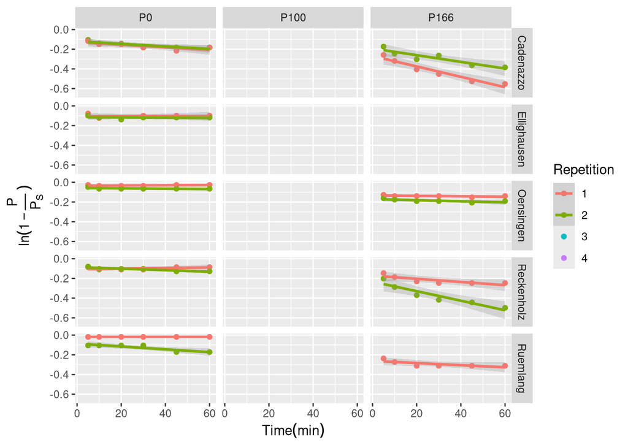

```r
ggplot(d, aes(y=Y1, x=t.min., col = Repetition)) +
  geom_point() +
  facet_grid(Site ~ Treatment) +
  labs(x=TeX("$Time (min)$"),
       y=TeX("$ln(1-\\frac{P}{P_S})$")) +
  geom_smooth(method="lm", alpha = 0.3)
```

The relation can be improved:

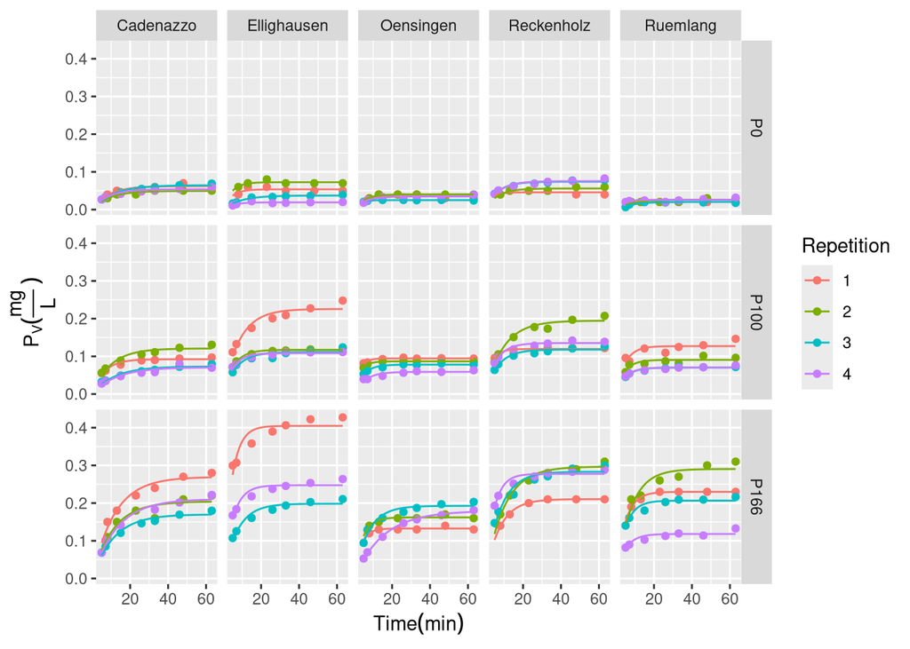

```r
#|code-fold: true
#|tidy: true
#|echo: false

Res <- nlsList(Pv.mg.L. ~ PS * (1 - exp(-k * (t.dt))) | uid, d[, c("Pv.mg.L.", "uid", "t.dt")],  start=list(PS=0.1,k=0.2))
# summary(Res)
# d$nls_pred <- predict(Res)

# Extract coefficients from the nlsList results
nls_coefs <- coef(Res)
nls_coefs$uid <- rownames(nls_coefs)

# Merge coefficients back to the main dataset
d_plot <- merge(d, nls_coefs, by = "uid")

# Most straightforward approach - create curves manually
time_seq <- seq(min(d$t.dt, na.rm = TRUE), max(d$t.dt, na.rm = TRUE), length.out = 100)

# Create prediction data
pred_data <- d_plot %>%
  select(uid, Site, Treatment, Repetition, PS, k) %>%
  distinct() %>%
  crossing(t.dt = time_seq) %>%
  mutate(pred_Pv = PS * (1 - exp(-k * (t.dt))))

# Final plot
p1 <- ggplot() +
  geom_point(data = d_plot, aes(y = Pv.mg.L., x = t.dt, col = Repetition)) +
  geom_line(data = pred_data, aes(x = t.dt, y = pred_Pv, col = Repetition), size = 0.5) +
  facet_grid(Treatment ~ Site) +
  labs(x = TeX("$Time (min)$"),
       y = TeX("$P_{V}(\\frac{mg}{L})$")); suppressWarnings(print(p1))
```

Now we see how those parameters depend on the tratment:

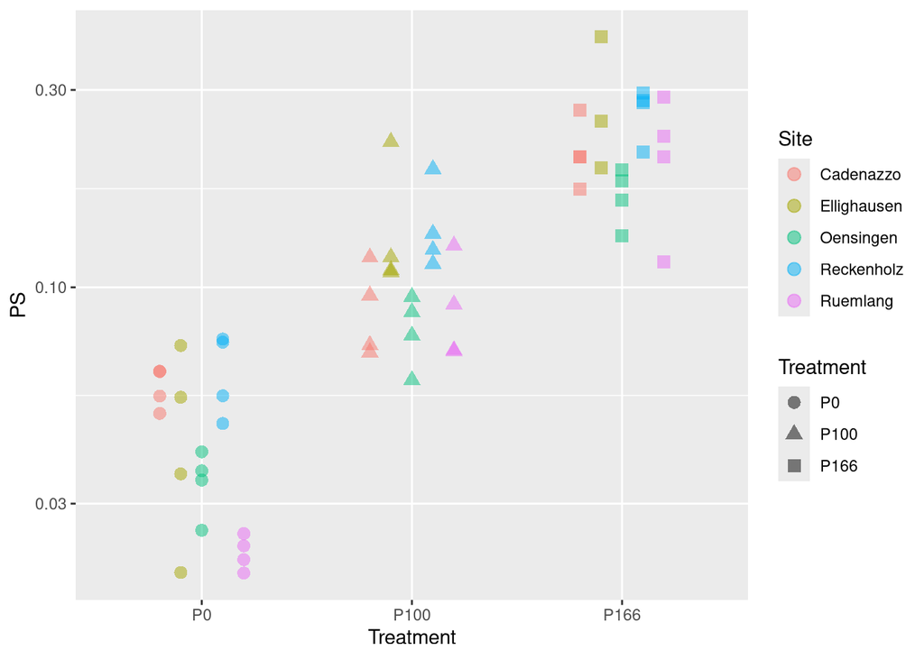

```r
#|code-fold: true
#|tidy: true
#|echo: false

d$ui <- interaction(d$Site, d$Treatment)

nlme.coef.avg <- list()
nlme.coef <- list()
for (lvl in levels(d$ui)){
  d.tmp <- subset(d, ui == lvl)
  # first get nlsList coefs for comparison only (unused)
  temp_nls <- coef(nlsList(Pv.mg.L. ~ PS * (1 - exp(-k * t.dt)) | uid,
                    d.tmp[, c("Pv.mg.L.", "uid", "t.dt")],
                    start = list(PS = 0.1, k = 0.2)))
  nlsList_coefs <- c(apply(temp_nls, 2, \(x) c(mean=mean(x), sd=sd(x))))
  names(nlsList_coefs) <- c("PS.mean", "PS.sd", "k.mean", "k.sd")

  # now do the real thing
  model4 <- nlme(Pv.mg.L. ~ PS * (1 - exp(-k * t.dt)),
                fixed = PS + k ~ 1,
                random = PS + k  ~ 1 | uid,
                data = d.tmp[, c("Pv.mg.L.", "uid", "t.dt")],
                start = c(PS = 0.05, k = 0.12),
                control = nlmeControl(maxIter = 200))
  coef(model4)
  fixef <- model4$coefficients$fixed
  ranefs <- ranef(model4)
  colnames(ranefs) <- paste0("ranef_",colnames(ranefs))
  nlme.coef[[lvl]]  <- cbind(coef(model4), ranefs, Rep=1:nrow(ranef(model4)), ui=lvl, Site=d.tmp[1, "Site"], Treatment=d.tmp[1, "Treatment"], uid = rownames(coef(model4)))
  nlme.coef.avg[[lvl]] <- data.frame(PS=fixef["PS"], k=fixef["k"], ui=lvl, Site=d.tmp[1, "Site"], Treatment=d.tmp[1, "Treatment"], uid = d.tmp$uid)
}
nlme.coef.avg <- do.call(rbind, nlme.coef.avg)
# folgendes datenset wollen wir benutzen um ihn mit dem Boden zu kombinieren
nlme.coef <- do.call(rbind, nlme.coef)
points <- geom_point(position=position_dodge(width=0.5), size = 3, alpha = 0.5)

ggplot(nlme.coef, aes(y=PS  , x=Treatment, col=Site, pch=Treatment)) + points + scale_y_log10()
```

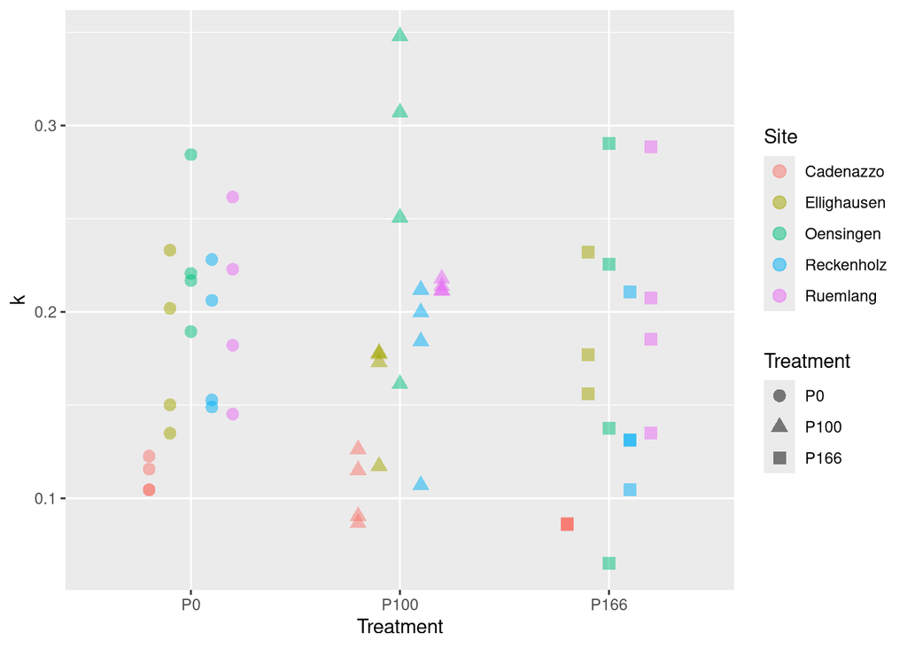

```r
ggplot(nlme.coef, aes(y=k   , x=Treatment, col=Site, pch=Treatment)) + points
```

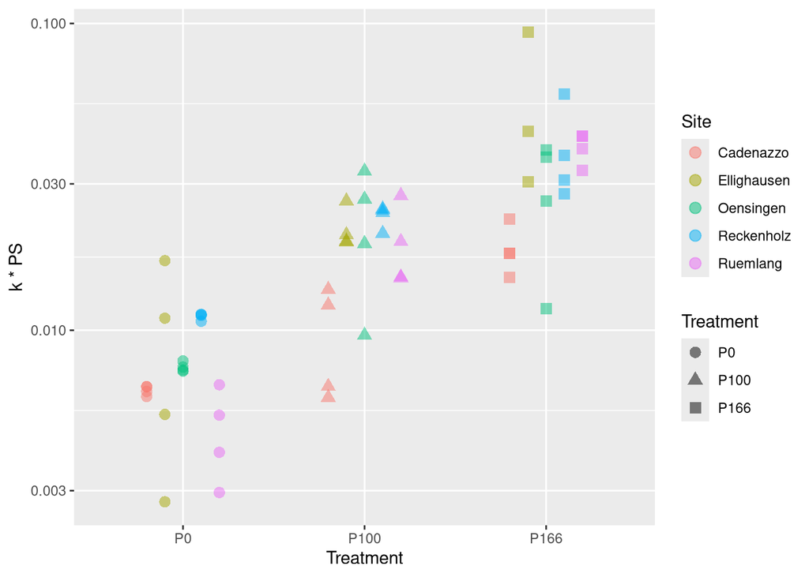

```r
ggplot(nlme.coef, aes(y=k*PS, x=Treatment, col=Site, pch=Treatment)) + points + scale_y_log10()
```

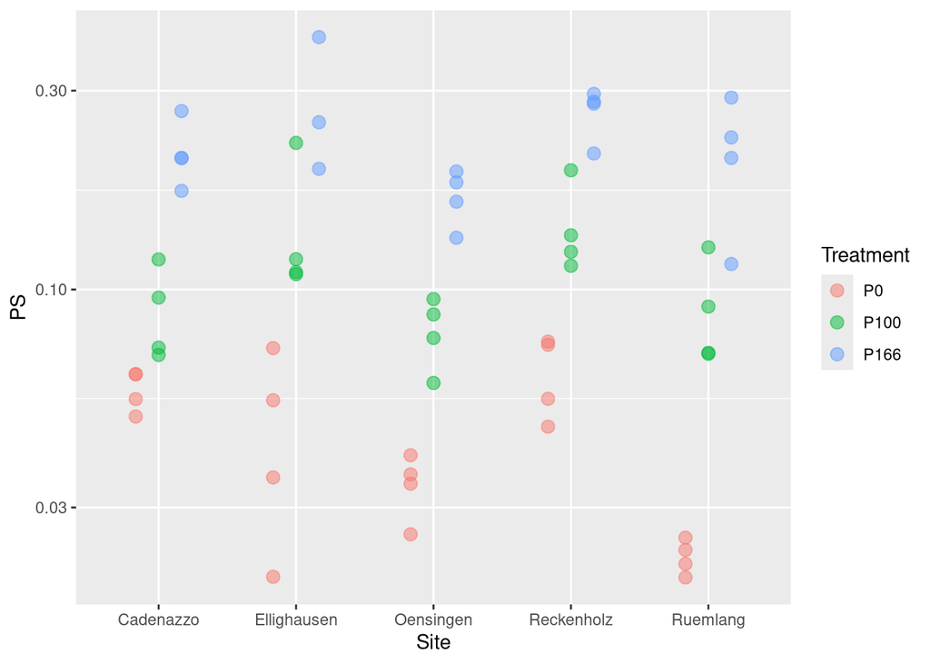

```r
ggplot(nlme.coef, aes(y=PS  , x=Site, col=Treatment)) + points + scale_y_log10()
```

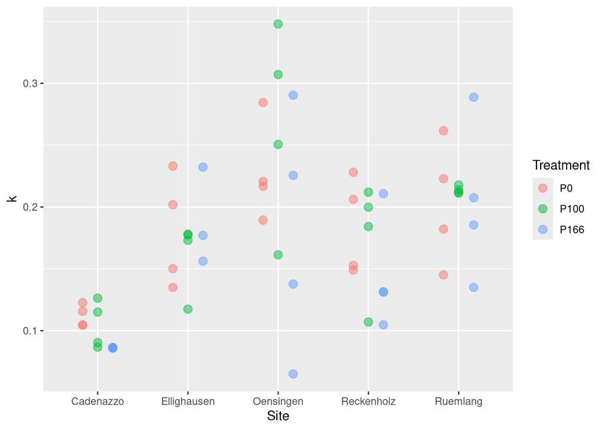

```r
ggplot(nlme.coef, aes(y=k   , x=Site, col=Treatment)) + points
```

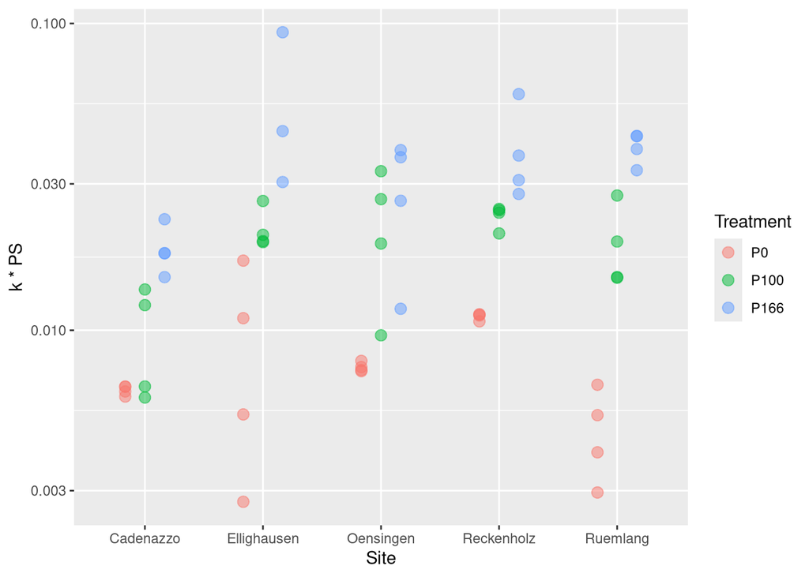

```r
ggplot(nlme.coef, aes(y=k*PS, x=Site, col=Treatment)) + points + scale_y_log10()
```

```r
# k PS macht von der interpretation her Sinn
# aber PS ist log-normal verteilt


fit.PS   <- lm(log(PS)      ~ Treatment + Site, nlme.coef)
fit.k    <- lm(k            ~ Treatment + Site, nlme.coef)
fit.kPS  <- lm(I(log(k*PS)) ~ Treatment + Site, nlme.coef)


Anova(fit.PS)
```

```
Anova Table (Type II tests)

Response: log(PS)
           Sum Sq Df  F value    Pr(>F)
Treatment 27.6260  2 154.7655 < 2.2e-16 ***
Site       3.0383  4   8.5104 2.324e-05 ***
Residuals  4.6411 52
---
Signif. codes:  0 '***' 0.001 '**' 0.01 '*' 0.05 '.' 0.1 ' ' 1
```

```r
summary(glht(fit.PS, mcp(Treatment = "Tukey")))
```

```
     Simultaneous Tests for General Linear Hypotheses

Multiple Comparisons of Means: Tukey Contrasts


Fit: lm(formula = log(PS) ~ Treatment + Site, data = nlme.coef)

Linear Hypotheses:
                 Estimate Std. Error t value Pr(>|t|)
P100 - P0 == 0    0.91948    0.09447   9.733  < 1e-10 ***
P166 - P0 == 0    1.68127    0.09580  17.550  < 1e-10 ***
P166 - P100 == 0  0.76179    0.09580   7.952 1.01e-10 ***
---
Signif. codes:  0 '***' 0.001 '**' 0.01 '*' 0.05 '.' 0.1 ' ' 1
(Adjusted p values reported -- single-step method)
```

```r
# Fazit: PS wird von treatment stark beeinfluss, k eher nicht (dafür von site)
Anova(fit.k)
```

```
Anova Table (Type II tests)

Response: k
            Sum Sq Df F value    Pr(>F)
Treatment 0.007374  2  1.6124    0.2092
Site      0.108427  4 11.8547 6.442e-07 ***
Residuals 0.118902 52
---
Signif. codes:  0 '***' 0.001 '**' 0.01 '*' 0.05 '.' 0.1 ' ' 1
```

```r
summary(glht(fit.k, mcp(Treatment = "Tukey")))
```

```
     Simultaneous Tests for General Linear Hypotheses

Multiple Comparisons of Means: Tukey Contrasts


Fit: lm(formula = k ~ Treatment + Site, data = nlme.coef)

Linear Hypotheses:
                  Estimate Std. Error t value Pr(>|t|)
P100 - P0 == 0    0.003111   0.015121   0.206    0.977
P166 - P0 == 0   -0.022243   0.015334  -1.451    0.323
P166 - P100 == 0 -0.025354   0.015334  -1.653    0.233
(Adjusted p values reported -- single-step method)
```

```r
Anova(fit.kPS)
```

```
Anova Table (Type II tests)

Response: I(log(k * PS))
           Sum Sq Df F value    Pr(>F)
Treatment 22.4177  2 68.5970 2.609e-15 ***
Site       3.9298  4  6.0124 0.0004703 ***
Residuals  8.4969 52
---
Signif. codes:  0 '***' 0.001 '**' 0.01 '*' 0.05 '.' 0.1 ' ' 1
```

```r
summary(glht(fit.kPS, mcp(Treatment = "Tukey")))
```

```
     Simultaneous Tests for General Linear Hypotheses

Multiple Comparisons of Means: Tukey Contrasts


Fit: lm(formula = I(log(k * PS)) ~ Treatment + Site, data = nlme.coef)

Linear Hypotheses:
                 Estimate Std. Error t value Pr(>|t|)
P100 - P0 == 0     0.9127     0.1278   7.140   <1e-04 ***
P166 - P0 == 0     1.5035     0.1296  11.599   <1e-04 ***
P166 - P100 == 0   0.5908     0.1296   4.558   <1e-04 ***
---
Signif. codes:  0 '***' 0.001 '**' 0.01 '*' 0.05 '.' 0.1 ' ' 1
(Adjusted p values reported -- single-step method)
```

```r
anova(fit.soil.PS)
```

```
Type III Analysis of Variance Table with Satterthwaite's method
                  Sum Sq Mean Sq NumDF  DenDF  F value    Pr(>F)
soil_0_20_clay    0.0719  0.0719     1 70.835   2.3900 0.1265690
soil_0_20_pH_H2O  0.0152  0.0152     1 89.035   0.5061 0.4787086
soil_0_20_Corg    0.4704  0.4704     1 65.081  15.6423 0.0001915 ***
soil_0_20_silt    0.1061  0.1061     1 70.745   3.5286 0.0644392 .
Treatment        10.0459  5.0230     2  6.055 167.0386 5.047e-06 ***
---
Signif. codes:  0 '***' 0.001 '**' 0.01 '*' 0.05 '.' 0.1 ' ' 1
```

```r
#summary(glht(fit.PS))
# Fazit: PS wird von treatment stark beeinfluss, k eher nicht (dafür von site)
anova(fit.soil.k)
```

```
Type III Analysis of Variance Table with Satterthwaite's method
                    Sum Sq   Mean Sq NumDF   DenDF F value   Pr(>F)
soil_0_20_clay   0.0098143 0.0098143     1  69.314 10.0428 0.002277 **
soil_0_20_pH_H2O 0.0091422 0.0091422     1 102.384  9.3551 0.002838 **
soil_0_20_Corg   0.0014112 0.0014112     1  98.359  1.4440 0.232372
soil_0_20_silt   0.0046704 0.0046704     1  75.910  4.7792 0.031888 *
Treatment        0.0059043 0.0029521     2   5.405  3.0209 0.131613
---
Signif. codes:  0 '***' 0.001 '**' 0.01 '*' 0.05 '.' 0.1 ' ' 1
```

```r
summary(glht(fit.soil.k))
```

```
     Simultaneous Tests for General Linear Hypotheses

Fit: lmer(formula = k ~ soil_0_20_clay + soil_0_20_pH_H2O + soil_0_20_Corg +
    soil_0_20_silt + Treatment + (1 | year) + (1 | Site) + (1 |
    Site:block) + (1 | Site:Treatment), data = D)

Linear Hypotheses:
                       Estimate Std. Error z value Pr(>|z|)
(Intercept) == 0       0.074168   0.150771   0.492   0.9965
soil_0_20_clay == 0   -0.007001   0.002209  -3.169   0.0103 *
soil_0_20_pH_H2O == 0  0.033720   0.011024   3.059   0.0147 *
soil_0_20_Corg == 0   -0.034533   0.028737  -1.202   0.7770
soil_0_20_silt == 0    0.005864   0.002683   2.186   0.1652
TreatmentP100 == 0     0.003910   0.015506   0.252   0.9999
TreatmentP166 == 0    -0.031147   0.015685  -1.986   0.2543
---
Signif. codes:  0 '***' 0.001 '**' 0.01 '*' 0.05 '.' 0.1 ' ' 1
(Adjusted p values reported -- single-step method)
```

```r
anova(fit.soil.kPS)
```

```
Type III Analysis of Variance Table with Satterthwaite's method
                 Sum Sq Mean Sq NumDF   DenDF F value   Pr(>F)
soil_0_20_clay   0.0055 0.00551     1  77.626  0.1043 0.747639
soil_0_20_pH_H2O 0.3773 0.37731     1 101.942  7.1335 0.008807 **
soil_0_20_Corg   0.0105 0.01052     1  93.639  0.1990 0.656575
soil_0_20_silt   0.0036 0.00360     1  80.228  0.0681 0.794743
Treatment        4.0339 2.01697     2   5.847 38.1329 0.000442 ***
---
Signif. codes:  0 '***' 0.001 '**' 0.01 '*' 0.05 '.' 0.1 ' ' 1
```

```r
summary(glht(fit.soil.kPS))
```

```
     Simultaneous Tests for General Linear Hypotheses

Fit: lmer(formula = I(log(k * PS)) ~ soil_0_20_clay + soil_0_20_pH_H2O +
    soil_0_20_Corg + soil_0_20_silt + Treatment + (1 | year) +
    (1 | Site) + (1 | Site:block) + (1 | Site:Treatment), data = D)

Linear Hypotheses:
                       Estimate Std. Error z value Pr(>|z|)
(Intercept) == 0      -6.657570   1.107392  -6.012   <0.001 ***
soil_0_20_clay == 0   -0.005316   0.016463  -0.323   0.9997
soil_0_20_pH_H2O == 0  0.216354   0.081005   2.671   0.0476 *
soil_0_20_Corg == 0    0.094691   0.212278   0.446   0.9980
soil_0_20_silt == 0    0.005221   0.020000   0.261   0.9999
TreatmentP100 == 0     1.064948   0.189188   5.629   <0.001 ***
TreatmentP166 == 0     1.634290   0.190050   8.599   <0.001 ***
---
Signif. codes:  0 '***' 0.001 '**' 0.01 '*' 0.05 '.' 0.1 ' ' 1
(Adjusted p values reported -- single-step method)
```